# R Markdown - Un support pour diffuser ses résultats. Exemple appliqué à l’analyse des évolutions de population observées dans le département du Rhône

Ronan Ysebaert, Hugues Pécout, 2018

Décembre 2018

# Import des données

Données INSEE (populations légales 1968-2015), géométries communales (IGN) et appartenances territoriales (EPCI).

```r
# Importer à partir d'un fichier Excel (INSEE)
library(readxl)
data2015 <- data.frame(read_excel("data/Fichier_poplegale_6815.xlsx", skip = 7, sheet = "2015"))
data1990 <- data.frame(read_excel("data/Fichier_poplegale_6815.xlsx", skip = 7, sheet = "1990"))
data1975 <- data.frame(read_excel("data/Fichier_poplegale_6815.xlsx", skip = 7, sheet = "1975"))

# Importer des géométries communales (IGN - Geofla 2016)
library(sf)
communes <- st_read(dsn = "data/COMMUNE.shp", stringsAsFactors = F)
# Importer l'appartenance intercommunale des communes de la Métropole du Grand Paris
EPT <- read.csv(file = "data/EPT_Lyon.csv", sep = ";", stringsAsFactors = F,encoding = "UTF-8" )
EPT$INSEE_COM <- as.character(EPT$INSEE_COM)
```

Code communal (INSEE) utile pour le calcul de distance.

```r
# Définir un centre (pour les calculs de distance)
moncentre <- "69123"
```

# Manipulation de données

Mise en forme des données pour les traitements ultérieurs.

```r
# Jointure : On regroupe les objets data2015, data1990 et data1975 en un seul objet "data"
data <- merge(data2015, data1990, by.x = "COM", by.y = "COM", all.x = T)
data <- merge(data, data1975, by.x = "COM", by.y = "COM", all.x = T)

# Jointure 2 : On regroupe avec les Etablissements publics territoriaux d'appartenance
data <- merge(data, EPT, by.x = "COM", by.y = "INSEE_COM", all.y = T)

# Jointure 3 : On ne conserve que les communes de la MGP
communes <- merge(communes, EPT, by.x = "INSEE_COM", by.y = "INSEE_COM")

# Supprimer les objets inutiles (pas obligatoire mais permet d'y voir plus clair... Dans les faits on réalise plutôt cette opération à la fin du programme)
rm(data1975,data1990,data2015,EPT)

# Conserver uniquement certaines variables et les renommer
fields <- c("COM", "NCC.x", "PSDC75", "PSDC90", "PMUN15", "EPT", "EPT_Nom")
data <- data[,fields]
colnames(data) <- c("COM","Nom","POP_1975","POP_1990","POP_2015", "EPT", "EPT_Nom")

# Créer de nouveaux indicateurs à partir de variables pré-existantes
# Variable quantitative : taux de croissance moyens annuels 1975-1990, 1990-2015 et 1990-2015
data$acc_7590 <- 100 * (exp(log(data$POP_1990 / data$POP_1975) / (1990 - 1975))-1)
data$acc_9015 <- 100 * (exp(log(data$POP_2015 / data$POP_1990) / (2015 - 1990))-1)
data$acc_7515 <- 100 * (exp(log(data$POP_2015 / data$POP_1975) / (2015 - 1975))-1)
head(data)
```

|  | COM | Nom | POP_1975 | POP_1990 | POP_2015 | EPT | EPT_Nom | acc_7590 | acc_9015 | acc_7515 |
| --- | --- | --- | --- | --- | --- | --- | --- | --- | --- | --- |
| 1 | 69001 | Affoux | 183 | 202 | 348 | COR | Communauté l'Ouest Rhodanien | 0.6607168 | 2.1995809 | 1.6197691 |
| 2 | 69002 | Aigueperse | 360 | 240 | 253 | CCHB | CC du Haut Beaujolais | -2.6668939 | 0.2112250 | -0.8779100 |
| 3 | 69003 | Albigny-sur-Saône | 2405 | 2836 | 2836 | LYON | Métropole de LYON | 1.1050255 | 0.0000000 | 0.4129621 |
| 4 | 69004 | Alix | 842 | 665 | 753 | CCBPD | Communauté de Communes Beaujolais Pierres Dorées | -1.5609750 | 0.4983504 | -0.2788973 |
| 5 | 69005 | Ambérieux | 326 | 378 | 563 | CCBPD | Communauté de Communes Beaujolais Pierres Dorées | 0.9915288 | 1.6063063 | 1.3753274 |
| 6 | 69006 | Amplepuis | 5340 | 4839 | 5072 | COR | Communauté l'Ouest Rhodanien | -0.6546317 | 0.1882856 | -0.1286433 |

```r
# Variable qualitative : un petit test conditionnel (quelles communes sont en croissance démographique ?)
data$typo9015 <- ifelse(data$acc_9015 >= 0 & data$acc_9015 < 1, "POP+ (0-1%)",
                        ifelse(data$acc_9015 > 1, "POP++ (+1%)",
                               "POP- (<0%)"))

# Extraite une chaine de caractère : département d'appartenance de chaque commune ?
library(stringr)
data$DEP <- str_sub(data$COM,  1, 2)

# Et si on aggrégeait le fond communal en EPT ?
library(dplyr)
agg <- communes %>% group_by(EPT) %>% summarize(names = first(EPT_Nom))
```

# Quelques statistiques et représentations graphiques associées

## Statistiques de base

Résumé statistique des indicateurs

```r
summary(data)
```

```
##      COM                Nom               POP_1975
##  Length:284         Length:284         Min.   :    56.0
##  Class :character   Class :character   1st Qu.:   446.5
##  Mode  :character   Mode  :character   Median :   832.0
##                                        Mean   :  5089.7
##                                        3rd Qu.:  2144.0
##                                        Max.   :456716.0
##                                        NA's   :5
##     POP_1990           POP_2015            EPT
##  Min.   :    51.0   Min.   :    67.0   Length:284
##  1st Qu.:   565.5   1st Qu.:   780.5   Class :character
##  Median :  1044.0   Median :  1460.0   Mode  :character
##  Mean   :  5370.3   Mean   :  6524.0
##  3rd Qu.:  2962.0   3rd Qu.:  4096.5
##  Max.   :415487.0   Max.   :513275.0
##  NA's   :5          NA's   :5
##    EPT_Nom             acc_7590          acc_9015          acc_7515
##  Length:284         Min.   :-4.2608   Min.   :-1.0046   Min.   :-1.4205
##  Class :character   1st Qu.: 0.3657   1st Qu.: 0.7533   1st Qu.: 0.7249
##  Mode  :character   Median : 1.4426   Median : 1.1833   Median : 1.3753
##                     Mean   : 1.5075   Mean   : 1.2359   Mean   : 1.3336
##                     3rd Qu.: 2.5390   3rd Qu.: 1.6477   3rd Qu.: 1.9259
##                     Max.   : 9.3182   Max.   : 6.2768   Max.   : 4.4010
##                     NA's   :5         NA's   :5         NA's   :5
##    typo9015             DEP
##  Length:284         Length:284
##  Class :character   Class :character
##  Mode  :character   Mode  :character
##
##
##
##
```

## Calcul de distances

Calcul de distances depuis un centre identifié, Lyon dans ce cas.

```r
monpoly <- communes[communes$INSEE_COM == moncentre,]
communes$distance <- c(st_distance(st_centroid(x = monpoly), st_centroid(x = communes)))
communes$distance <- as.numeric(communes$distance)
data <- merge(x = data, y = communes[,c("INSEE_COM","distance")], by.x = "COM", by.y = "INSEE_COM", all.x = TRUE)
```

## Populations communales aux différentes dates de recensement

Les communes du département du Rhône sont globalement faiblement peuplées à l’exception des communes de la métropole lyonnaise…

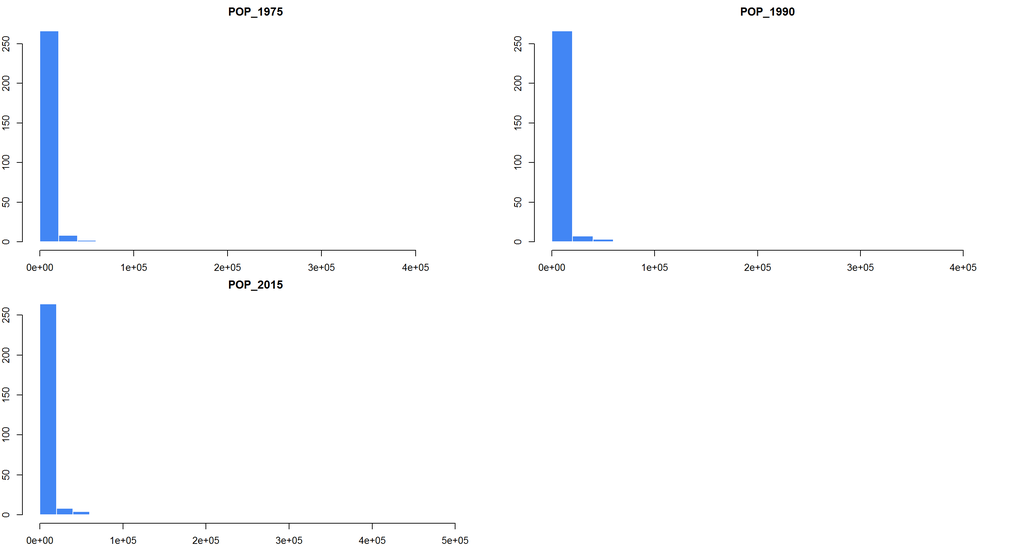

```r
par(mar = c(2,2,2,2))
par(mfrow = c(2,2))

for (i in 3:5){ # On prend les colonnes 3 à 5 du dataframe
  popYear <- colnames(data) # récupérer le nom des colonnes
  hist(data[ ,i], # un histogramme
       breaks = 20, # la série statistique est coupée en 20 classes
       main = popYear[i], # titre
       col = "#4286f4", # couleur des barres
       border = "white", # couleur des bordures
       xlab = "Population", # titre de l'axe des X
       ylab = "Fréquence") # titre de l'axe des Y
}
```

## Relation distance au centre de la Métropole et accroissement de la population ?

Il existe une relation significative entre la distance à la métropole lyonnaise et le taux d’accroissement de la population pour la période 1975-1990, mais pas pour la période 1990-2015

```r
cor.test(data$acc_9015, data$distance)
```

```
##
##  Pearson's product-moment correlation
##
## data:  data$acc_9015 and data$distance
## t = 0.062526, df = 277, p-value = 0.9502
## alternative hypothesis: true correlation is not equal to 0
## 95 percent confidence interval:
##  -0.113725  0.121135
## sample estimates:
##         cor
## 0.003756817
```

```r
cor.test(data$acc_7590, data$distance)
```

```
##
##  Pearson's product-moment correlation
##
## data:  data$acc_7590 and data$distance
## t = -9.295, df = 277, p-value < 2.2e-16
## alternative hypothesis: true correlation is not equal to 0
## 95 percent confidence interval:
##  -0.5722575 -0.3926432
## sample estimates:
##        cor
## -0.4875926
```

En analysant les graphiques, on constate que cette relation est négative. En d’autres termes, plus la distance augmente moins l’accroissement de la population était important sur la période 1975-1990.

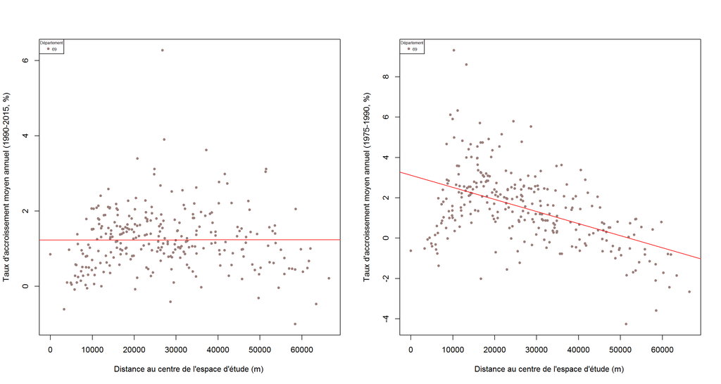

```r
data$DEP <- as.factor(data$DEP)

library(cartography)
colours <- carto.pal(pal1 = "multi.pal", n1 = nlevels(data$DEP)) # 1 couleur par dépt

# Assigner les couleurs aux départements d'appartenance
data <-data[order(data$DEP, decreasing = FALSE), ]
data$col <- as.factor(data$DEP)
levels(data$col) <- colours
# Représentation graphique
par(mfrow = c(1,2))
plot(data$distance, data$acc_9015,
     ylab = "Taux d'accroissement moyen annuel (1990-2015, %)",
     xlab = "Distance au centre de l'espace d'étude (m) ",
     pch = 20,
     col = as.vector(data$col))
# Afficher la régression linéaire
abline((lm(data$acc_9015 ~ data$distance)), col = "red", lwd =1)
# Afficher la légende
data$DEP <- as.factor(data$DEP)
legend("topleft", legend = levels(data$DEP),pch = 20,col = colours, cex = 0.5, pt.cex = 1,
       title = "Département")

# Il suffirait de quelques modifications dans le code pour reproduire cette analyse avec
# le taux d'accroissement sur la précédente période censitaire !
# Représentation graphique
plot(data$distance, data$acc_7590,
     ylab = "Taux d'accroissement moyen annuel (1975-1990, %)",
     xlab = "Distance au centre de l'espace d'étude (m) ",
     pch = 20,
     col = as.vector(data$col))
# Afficher la régression linéaire
abline((lm(data$acc_7590 ~ data$distance)), col = "red", lwd =1)
# Afficher la légende
data$DEP <- as.factor(data$DEP)
legend("topleft", legend = levels(data$DEP),pch = 20,col = colours, cex = 0.5, pt.cex = 1,
       title = "Département")
```

## Effet d’appartenance à l’EPCI pour des catégories d’accroissement de population ?

```r
tab <- table(data$typo9015, data$EPT_Nom)
tab.chi2 <- chisq.test(tab)
tab.chi2
```

```
##
##  Pearson's Chi-squared test
##
## data:  tab
## X-squared = 59.297, df = 28, p-value = 0.0005005
```

La preuve avec ce diagramme en bâtons…

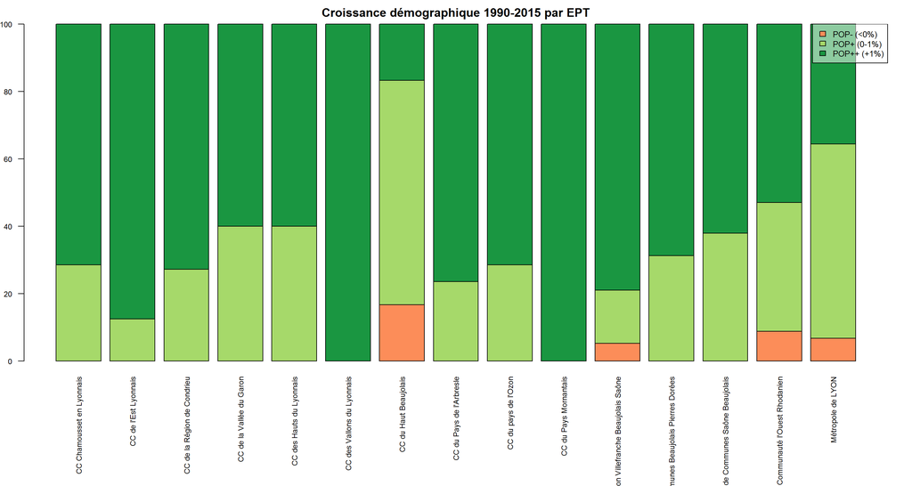

```r
library(questionr)
ctab <- cprop(tab, total = FALSE)
# Diagramme en bâton
par(mar = c(10,2,2,2))
col <- c("#fc8d59","#a6d96a","#1a9641")
barplot(ctab, main = "Croissance démographique 1990-2015 par EPT",las = 2, col= col,
        cex.axis=0.75, cex.names = 0.75)
legend("topright", c("POP- (<0%)", "POP+ (0-1%)","POP++ (+1%)"), fill = col, cex = 0.8, bg = "#ffffff80")
```

## Taux de croissances de la population ventilés par EPCI (boxplot)

Allons plus loin, qu’en est-il quand nous analysons plus en détails les valeurs de ces taux de croissance ?

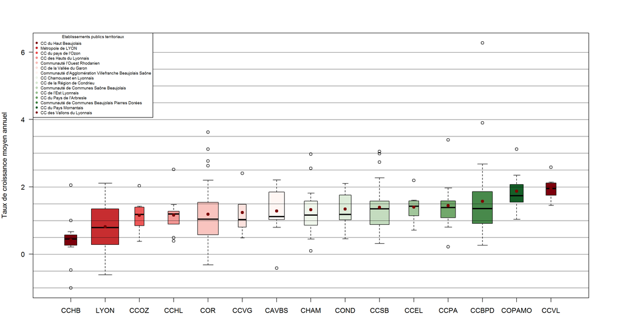

```r
data$EPT <- with(data, reorder(EPT, acc_9015, mean, na.rm = TRUE))

col <- carto.pal(pal1 = "red.pal", n1 = (nlevels(data$EPT)/2), pal2 = "green.pal", n2 = (nlevels(data$EPT)/2),
                 middle = FALSE, transparency = TRUE)

par(mar = c(4,4,4,4))
boxplot(data$acc_9015 ~ data$EPT,
        col = col,
        ylab = "Taux de croissance moyen annuel",
        varwidth = TRUE,
        range = 1,
        outline = TRUE,
        las = 1)

# Ligne de repère
abline (h = seq(min(data$acc_9015,na.rm=T),max(data$acc_9015,na.rm=T),0.5), col = "#00000080", lwd = 1, lty = 1)

# Représenter les valeurs moyennes
xi<- tapply(data$acc_9015, data$EPT, mean, na.rm = T)
points(xi,col="#7C0000",pch=19)

# Legend for the boxplot
data$EPT_Nom<- as.factor(data$EPT_Nom)
data$EPT_Nom <- with(data, reorder(EPT_Nom, acc_9015, mean, na.rm = TRUE))
legend("topleft",
       legend = levels(data$EPT_Nom),
       pch = 20,
       col = col,
       cex = 0.6,
       pt.cex = 1,
       title = "Etablissements publics territoriaux")
```

La croissance démographique la plus faible (en moyenne) a été observée dans la communauté de communes des Hauts du Beaujolais, la plus forte dans la communauté de communes des Vallons du Lyonnais. La métropole de Lyon représente l’EPCI avec la 2ème plus faible croissance démographique sur la période. On peut néanmoins noter la forte dispersion existant au sein de chaque EPCI. En revanche l’EPCI des Vallons du Lyonnais se caractérise par une croissance démographique homogène sur la période, autour de 2%.

# Analyse cartographique

## Cartes de discontinuités

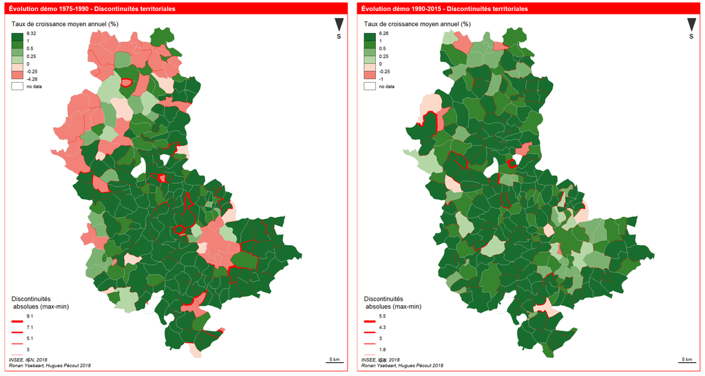

```r
#  Cartographie
library(cartography)

# On joint les colonnes du dataframe utiles à la carto
communes <- merge(x = communes, y = data[,c("COM","POP_1975","POP_1990","POP_2015", "acc_9015","acc_7590")],
                  by.x = "INSEE_COM", by.y = "COM", all.x = TRUE)


# Cartographie de discontinuités (choro layer +  discLayer)
par(mfrow=c(1,2))
par(mar = c(0.5,0.5,1.5,0.5)) # Ajuster les marges

cols <- carto.pal(pal1 = "red.pal", pal2 = "green.pal",  n1 = 2, n2 = 4)

# 1975- 1990
plot(st_geometry(communes), col = NA, border = NA)

choroLayer(x = communes, var = "acc_7590",
           border = "grey80",
           col = cols,
           breaks = c(min(data$acc_7590,na.rm = T),-0.25,0,0.25,0.5,1,max(data$acc_7590,na.rm = T)),
           nclass = 10,
           legend.pos = "topleft",
           legend.values.rnd = 2,
           lwd=0.5,
           add = T,
           legend.title.txt = "Taux de croissance moyen annuel (%)")

borders <- getBorders(communes)

discLayer(x = borders, # sf
          df = communes,
          var = "acc_7590", # variable used to compute discontinuties
          type = "abs", # type of discontinuity measure
          method="equal", # discretisation of discontinuities
          nclass=4, # number of discontinuities classes
          threshold = 0.5, # representation threshold of discontinuities
          sizemin = 0.5, # minimum size of discontinuities lines
          sizemax = 6, # maximum size of discontinuities lines
          col="red", # color of the lines
          legend.values.rnd = 1,
          legend.title.txt = "Discontinuités \n absolues (max-min)",
          legend.pos = "bottomleft",
          add=TRUE)

layoutLayer(title = "Évolution démo 1975-1990 - Discontinuités territoriales",
            author = "Ronan Ysebaert, Hugues Pécout 2018", sources = "INSEE, IGN, 2018",
            scale = 5,
            frame = TRUE,
            col = "red",
            coltitle = "white",
            south = TRUE)


# 1990 - 2015
plot(st_geometry(communes), col = NA, border = NA)

choroLayer(x = communes, var = "acc_9015",
           border = "grey80",
           col = cols,
           breaks = c(min(data$acc_9015,na.rm = T),-0.25,0,0.25,0.5,1,max(data$acc_9015,na.rm = T)),
           nclass = 10,
           legend.pos = "topleft",
           legend.values.rnd = 2,
           lwd=0.5,
           add = T,
           legend.title.txt = "Taux de croissance moyen annuel (%)")

discLayer(x = borders, # sf
          df = communes,
          var = "acc_9015", # variable used to compute discontinuties
          type = "abs", # type of discontinuity measure
          method="equal", # discretisation of discontinuities
          nclass=4, # number of discontinuities classes
          threshold = 0.5, # representation threshold of discontinuities
          sizemin = 0.5, # minimum size of discontinuities lines
          sizemax = 6, # maximum size of discontinuities lines
          col="red", # color of the lines
          legend.values.rnd = 1,
          legend.title.txt = "Discontinuités \n absolues (max-min)",
          legend.pos = "bottomleft",
          add=TRUE)

layoutLayer(title = "Évolution démo 1990-2015 - Discontinuités territoriales",
            author = "Ronan Ysebaert, Hugues Pécout 2018", sources = "INSEE, IGN, 2018",
            scale = 5,
            frame = TRUE,
            col = "red",
            coltitle = "white",
            south = TRUE)
```

Sur la période 1975 - 1990, c’est la partie nord du département du Rhône qui est concernée par la décroissance de la population, ainsi que la métropole Lyonnaise. Cette tendance se confirme en s’atténuant sur la période 1990-2015 puisque ce sont ces mêmes territoires concernés par les croissances démographiques les plus faibles (qui sont malgré tout positives)… On observe néanmoins pas de ruptures territoriales franches au sein de cet espaces d’étude mais davantage des gradiants géographiques…

## Evolution de la population en fonction de la taille de la population

[figure not shown]

```r
par(mfrow=c(1,2))
par(mar = c(0.5,0.5,1.5,0.5)) # Ajuster les marges
# 1975 - 1990
plot(st_geometry(communes), col = "lightblue", border = NA)
plot(st_geometry(agg), col = NA, border = "white", lwd = 1, add = T)

propSymbolsChoroLayer(x = communes, var = "POP_1990", var2 = "acc_7590",
                      col = cols,
                      inches = 0.2,
                      breaks = c(min(data$acc_7590,na.rm = T),-0.25,0,0.25,0.5,1,max(data$acc_7590,na.rm = T)),
                      border = "grey50", lwd = 1,
                      legend.var.pos = "bottomleft", legend.var2.pos = "topleft",
                      legend.var2.title.txt =
                        "Taux de croissance moyen annuel (%)",
                      legend.var.title.txt = "Population totale 1990",
                      legend.var.style = "e",
                      add = T)

layoutLayer(title = "Évolution démo 1975-1990 et population 1990",
            author = "Ronan Ysebaert, Hugues Pécout 2018", sources = "INSEE, IGN, 2018",
            scale = 5,
            frame = TRUE,
            col = "red",
            coltitle = "white",
            south = TRUE)


# 1990 - 2015
plot(st_geometry(communes), col = "lightblue", border = NA)
plot(st_geometry(agg), col = NA, border = "white", lwd = 1, add = T)

propSymbolsChoroLayer(x = communes, var = "POP_2015", var2 = "acc_9015",
                      col = cols,
                      inches = 0.2,
                      breaks = c(min(data$acc_9015,na.rm = T),-0.25,0,0.25,0.5,1,max(data$acc_9015,na.rm = T)),
                      border = "grey50", lwd = 1,
                      legend.var.pos = "bottomleft", legend.var2.pos = "topleft",
                      legend.var2.title.txt =
                        "Taux de croissance moyen annuel (%)",
                      legend.var.title.txt = "Population totale 2015",
                      legend.var.style = "e",
                      add = T)

layoutLayer(title = "Évolution démo 1990-2015 et population 2015",
            author = "Ronan Ysebaert, Hugues Pécout 2018", sources = "INSEE, IGN, 2018",
            scale = 5,
            frame = TRUE,
            col = "red",
            coltitle = "white",
            south = TRUE)
```

La décroissance de population observée au nord concerne avant tout des communes faiblement peuplées…

## S’abstraire du maillage en prenant en compte les masses : cartes de potentiel

```r
par(mfrow=c(1,2))
par(mar = c(0.5,0.5,1.5,0.5)) # Ajuster les marges

plot(st_geometry(communes), col = NA, border = NA)

distr <- communes$POP_1990 / communes$POP_1975
summary(distr)
```

```
##    Min. 1st Qu.  Median    Mean 3rd Qu.    Max.    NA's
##  0.5204  1.0563  1.2397  1.2974  1.4566  3.8053       5
```

```r
cols <- carto.pal(pal1 = "red.pal", pal2 = "green.pal",  n1 = 2, n2 = 5)

smoothLayer(x = communes,
            var = 'POP_1990', var2 = 'POP_1975',
            span = 2000, beta = 2,
            resolution = 500,
            legend.title.txt = "Potentiel de croissance de population, \n(pas de lissage = 2 km)",
            col = cols,
            breaks = c(min(communes$POP_1990/communes$POP_1975, na.rm=T),
                       0.95,1,1.05,1.1,1.15,1.2,
                       max(communes$POP_1990/communes$POP_1975, na.rm = T)),
            mask = st_buffer(communes,1),
            legend.pos = "topleft", legend.values.rnd = 2,
            add = T)

plot(st_geometry(agg), col = NA, border = "white", lwd = 1, add = T)

layoutLayer(title = "Croissance démographique 1975-1990 - carte de potentiel",
            author = "Ronan Ysebaert, Hugues Pécout 2018", sources = "INSEE, IGN, 2018",
            scale = 5,
            frame = TRUE,
            col = "red",
            coltitle = "white",
            south = TRUE)

# 1990-2015
plot(st_geometry(communes), col = NA, border = NA)

distr <- communes$POP_2015 / communes$POP_1990
summary(distr)
```

```
##    Min. 1st Qu.  Median    Mean 3rd Qu.    Max.    NA's
##  0.7769  1.2064  1.3419  1.3879  1.5047  4.5810       5
```

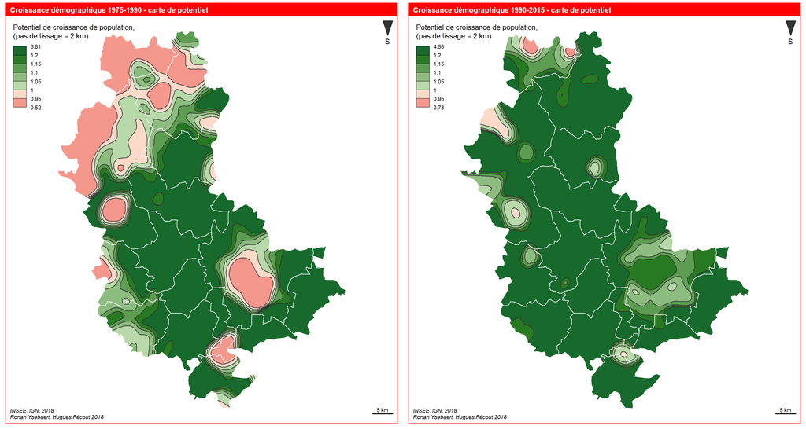

```r
cols <- carto.pal(pal1 = "red.pal", pal2 = "green.pal",  n1 = 2, n2 = 5)

smoothLayer(x = communes,
            var = 'POP_2015', var2 = 'POP_1990',
            span = 2000, beta = 2,
            resolution = 500,
            legend.title.txt = "Potentiel de croissance de population, \n(pas de lissage = 2 km)",
            col = cols,
            breaks = c(min(communes$POP_2015/communes$POP_1990, na.rm=T),
                       0.95,1,1.05,1.1,1.15,1.2,
                       max(communes$POP_2015/communes$POP_1990, na.rm = T)),
            mask = st_buffer(communes,1),
            legend.pos = "topleft", legend.values.rnd = 2,
            add = T)

plot(st_geometry(agg), col = NA, border = "white", lwd = 1, add = T)

layoutLayer(title = "Croissance démographique 1990-2015 - carte de potentiel",
            author = "Ronan Ysebaert, Hugues Pécout 2018", sources = "INSEE, IGN, 2018",
            scale = 5,
            frame = TRUE,
            col = "red",
            coltitle = "white",
            south = TRUE)
```

Ces représentations, basé sur le calcul de potentiels apportent une autre visualisation de ces phénomènes démographiques. On voit spécifiquement apparaître les pôles de décroissance de population sur la période 1975-1990. Pour la période 1990-2015, on constate que c’est surtout la périphérie de la métropole lyonnaise qui est concernée par une croissance démographique plus faible au regard du reste du territoire.